# R Notebook

# lec04 - Hypothesis testing

## Simulating data

Often we won’t have the expected data, so we must simulate the data manually. Firstly it it important to identify the null and alternative hypotheses, that way we know what we are measuring and what our expected data should look like.

[figure not shown]

```r
# observed counts
y = c(128, 86, 74,112)
n = sum(y)

#hypothesized proportions
p = c(.25, .25, .25, .25)

#expected counts
e = p*n

#Lets visualise the two.

names = c("C1", "C2", "C3", "C4")
par(mfrow = c(1,2), cex=1.5)
barplot(y, names.arg = names,
        main="Observed counts")
barplot(e, names.arg=names,
        main="Expected counts")
```

Intuitively the above plots do not look like a great fit, however scientific studies rely on rigor not intuition. So we will apply a test statistic to see. But first, we can do a couple of checks.

[figure not shown]

```r
library(tidyverse)
df = tibble(names,y,p,e)
df %>% ggplot() + aes(x=names,y=y)+
  geom_bar(stat="identity") +
  geom_hline(yintercept=100, colour="blue") +
  theme_minimal(base_size=32) +
  labs(x="",y="Count")
```

```r
d = y-e
sprintf("The differences are:")
```

```
[1] "The differences are:"
```

```r
print(d)
```

```
[1]  28 -14 -26  12
```

```r
sprintf("and the mean of the differences is %f", mean(d))
```

```
[1] "and the mean of the differences is 0.000000"
```

But this is still not very rigorous and the plot doesn’t give us enough information. So we will measure the similarity using a test statistic.

```r
t0 = sum((y-e)^2/e)
sprintf("The sum of squared differences normalised, equals: %f", t0)
```

```
[1] "The sum of squared differences normalised, equals: 18.000000"
```

```r
sprintf("Under the null hypothesis, the counts are uniformly distributed across 4 categories. Running a simulation to generate a random even distribution with 400 samples, results in:")
```

```
[1] "Under the null hypothesis, the counts are uniformly distributed across 4 categories. Running a simulation to generate a random even distribution with 400 samples, results in:"
```

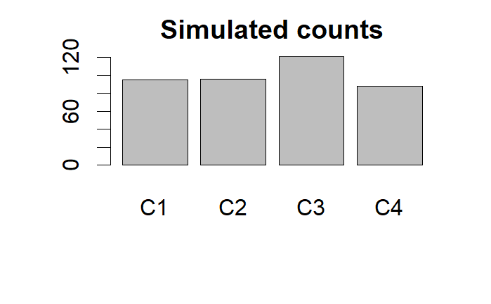

```r
n = 400
set.seed(1)
sim1 = sample(x=names, size=n, replace=TRUE, prob = e)
sim_y = table(sim1)
par(cex=2)
barplot(sim_y, main="Simulated counts")
```

Applying our test statistic to the above simulation yields the result:

```r
sum((sim_y-e)^2/e)
```

```
[1] 6.26
```

We can see that there is a significant difference between 6.26 and 18. However there could be alot of variance, so to ensure robustness, we should run the simulation a number of times.

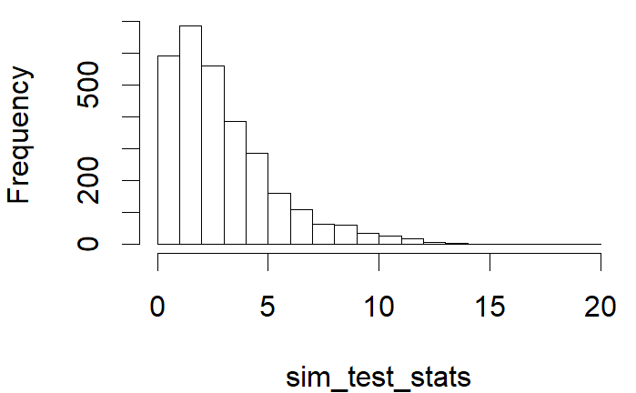

```r
runs = 3000
sim_test_stats = vector(mode="numeric", length=runs)
for(i in 1:runs){
  sim = table(sample(x=names, size=n, replace=TRUE,prob=e))
  sim_test_stats[i]=sum((sim-e)^2/e)
}
par(cex=2, mar=c(4,4,0.5,0.5))
hist(sim_test_stats, main="", breaks=20)
```

```r
sprintf("Likelihood %f percent", mean(sim_test_stats >= t0))
```

```
[1] "Likelihood 0.001000 percent"
```

However there is a much simpler way of doing this using the “infer” package (see lecture slides) BUT we can also do this without simulations. This can be done using the chi squared test.

```r
library(infer)
df_long = df %>% select(names, y) %>% uncount(weights=y)
probs = c("C1"=.25, "C2"=.25, "C3"=.25, "C4"=.25)
sim_study = df_long %>% specify(response=names) %>% hypothesize(null="point",p=probs) %>% generate(reps=3000,type="simulate") %>% calculate(stat="Chisq")
glimpse(sim_study)
```

```
Observations: 3,000
Variables: 2
$ replicate <fct> 1, 2, 3, 4, 5, 6, 7, 8, 9, 10, 11, 12, 13, 14, 15, 16, 17, 18, 19, 20, 21, 22, 23, 24, 25, 26, 27, 28, 29, 30, 31, 32, 33, 34, ...
$ stat      <dbl> 1.34, 4.06, 3.98, 2.42, 3.56, 3.08, 0.14, 3.24, 9.54, 4.70, 1.22, 1.54, 10.64, 1.46, 3.06, 0.82, 0.94, 2.66, 0.84, 2.04, 0.58, ...
```

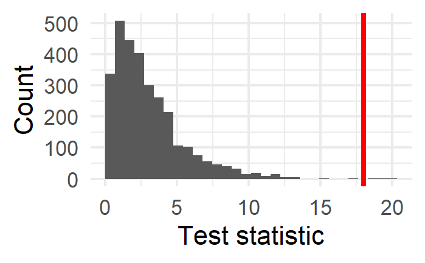

```r
sim_study %>% ggplot(aes(x=stat)) + geom_histogram(boundary=0) + theme_minimal(base_size=32) + geom_vline(xintercept=t0, colour="red", size=3)+ labs(x="Test statistic", y="Count")
```

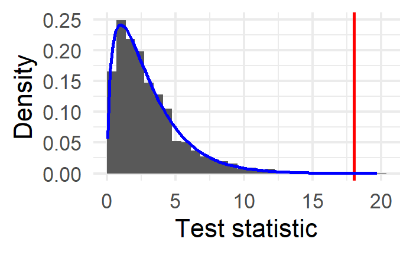

```r
sim_study %>% ggplot(aes(x=stat)) + geom_histogram(aes(y=..density..), boundary=0) + theme_minimal(base_size=32)+geom_vline(xintercept = t0,colour="red", size=2) + labs(x="Test statistic", y="Density") + stat_function(fun=dchisq, args=list(df=3), colour="blue", size=2)
```